# Lab-03

Mohamed Said

2022-04-05

**Part 1**

**Change in Home Values**

```r
import::here("clean_d",
             "tidy_up_data",
             "build_year",
             "RELEVANT_FILES",
             "obtain_crosswalk",
             "create_final_metadata_file",
             # notice the use of here::here() that points to the .R file
             # where all these R objects are created
             .from = here::here("labs/wk03/utilities.R"),
             .character_only = TRUE)
```

```r
# note: please do not use static file paths
# note: notice down below the use of here::here()
d1 <- readRDS( here::here( "data/rodeo/LTDB-1990.rds" ) )
d2 <- readRDS( here::here( "data/rodeo/LTDB-2000.rds" ) )
md <- readRDS( here::here( "data/rodeo/LTDB-META-DATA.rds" ) )
# check to make sure we are not losing
# or gaining observations in the merge
nrow( d1 )
```

```
## [1] 72693
```

```r
d1 <- select( d1, - year )
d2 <- select( d2, - year )
d <- merge( d1, d2, by="tractid" )
d <- merge( d, md, by="tractid" )
nrow( d )
```

```
## [1] 72693
```

**Filter Rural Districts**

```r
#urban districts only
table( d$urban )
```

```
##
## rural urban
## 12971 59722
```

```r
d <- filter( d, urban == "urban" )
```

**Identify Common Variables**

```r
# find common variables in both files
compare_dfs <- function( df1, df2 )
{
  # use regular expressions to remove numeric suffixes
  var.names.1 <- names( df1 )
  var.names.1 <- gsub( "[.][xy]$", "", var.names.1 )
  var.names.1 <- gsub( "[0-9]{2}$", "", var.names.1 )

  var.names.2 <- names( df2 )
  var.names.2 <- gsub( "[.][xy]$", "", var.names.2 )
  var.names.2 <- gsub( "[0-9]{2}$", "", var.names.2 )

  shared <- intersect( var.names.1, var.names.2 ) %>% sort()
  print( "SHARED VARIABLES:")
  print( shared )

  not.shared <- c( setdiff( var.names.1, var.names.2 ),
                   setdiff( var.names.2, var.names.1 ) ) %>% sort()

  print( "NOT SHARED:" )
  print( not.shared )

  d.vars1 <- data.frame( type="shared", variables=shared, stringsAsFactors=F )
  d.vars2 <- data.frame( type="not shared", variables=not.shared, stringsAsFactors=F )
  dd <- rbind( d.vars1, d.vars2 )

  return( dd )
}
vars <- compare_dfs( df1=d1, df2=d2 )
```

```
## [1] "SHARED VARIABLES:"
##   [1] "a15asn"  "a15blk"  "a15hsp"  "a15ntv"  "a15wht"  "a18und"  "a60asn"
##   [8] "a60blk"  "a60hsp"  "a60ntv"  "a60up"   "a60wht"  "a75up"   "ag15up"
##  [15] "ag25up"  "ag5up"   "ageasn"  "ageblk"  "agehsp"  "agentv"  "agewht"
##  [22] "asian"   "china"   "clf"     "cni16u"  "col"     "cuban"   "dapov"
##  [29] "dbpov"   "dflabf"  "dfmpov"  "dhpov"   "dis"     "dmulti"  "dnapov"
##  [36] "dpov"    "dwpov"   "empclf"  "family"  "fb"      "fhh"     "filip"
##  [43] "flabf"   "geanc"   "gefb"    "h10yrs"  "h30old"  "haw"     "hh"
##  [50] "hha"     "hhb"     "hhh"     "hhw"     "hinc"    "hinca"   "hincb"
##  [57] "hinch"   "hincw"   "hisp"    "hs"      "hu"      "incpc"   "india"
##  [64] "iranc"   "irfb"    "itanc"   "itfb"    "japan"   "korea"   "lep"
##  [71] "manuf"   "mar"     "mex"     "mhmval"  "mrent"   "multi"   "n10imm"
##  [78] "n65pov"  "napov"   "nat"     "nbpov"   "nfmpov"  "nhblk"   "nhpov"
##  [85] "nhwht"   "nnapov"  "npov"    "ntv"     "nwpov"   "ohu"     "olang"
##  [92] "own"     "pop"     "pr"      "prof"    "rent"    "ruanc"   "rufb"
##  [99] "scanc"   "scfb"    "semp"    "tractid" "unemp"   "vac"     "vet"
## [106] "viet"    "wds"
## [1] "NOT SHARED:"
## [1] "ag16cv"  "ag18cv"  "hu00sp"  "hu90sp"  "ohu00sp" "ohu90sp" "pop90.1"
```

```r
head( vars )
```

```
##     type variables
## 1 shared    a15asn
## 2 shared    a15blk
## 3 shared    a15hsp
## 4 shared    a15ntv
## 5 shared    a15wht
## 6 shared    a18und
```

**Create data set for analysis**

```r
d.full <- d  # keep a copy so don't have to reload
```

**1990-2000 variables**

```r
d <- d.full  # store original in case you need to reset anything
d <- select( d, tractid, mhmval90, mhmval00, hinc90, hinc00,
             hu90, own90, rent90,
             empclf90, clf90, unemp90, prof90,
             dpov90, npov90,
             ag25up90, hs90, col90,
             pop90.x, nhwht90, nhblk90, hisp90, asian90,  ## ? pop90 or pop90.x
             cbsa, cbsaname )
d <-
  d %>%
  mutate( p.white = 100 * nhwht90 / pop90.x,
          p.black = 100 * nhblk90 / pop90.x,
          p.hisp = 100 * hisp90 / pop90.x,
          p.asian = 100 * asian90 / pop90.x,
          p.hs = 100 * (hs90+col90) / ag25up90,
          p.col = 100 * col90 / ag25up90,
          p.prof = 100 * prof90 / empclf90,
          p.unemp = 100 * unemp90 / clf90,
          pov.rate = 100 * npov90 / dpov90 )
```

```r
stargazer( d,
           type = s.type,
           digits = 0,
           summary.stat = c( "min", "p25", "median", "mean", "p75", "max" ) )
```

| Statistic | Min | Pctl(25) | Median | Mean | Pctl(75) | Max |
| --- | --- | --- | --- | --- | --- | --- |
| mhmval90 | 0 | 58,800 | 86,500 | 112,399 | 141,800 | 500,001 |
| mhmval00 | 0 | 81,600 | 119,900 | 144,738 | 173,894 | 1,000,001 |
| hinc90 | 4,999 | 24,355 | 32,033 | 34,160 | 41,520 | 150,001 |
| hinc00 | 2,499 | 33,000 | 43,825 | 47,657 | 58,036 | 200,001 |
| hu90 | 0 | 916 | 1,337 | 1,382 | 1,804 | 11,003 |
| own90 | 0 | 422 | 744 | 788 | 1,093 | 8,180 |
| rent90 | 0 | 168 | 358 | 476 | 663 | 8,653 |
| empclf90 | 0 | 1,015 | 1,555 | 1,625 | 2,157 | 11,816 |
| clf90 | 0 | 1,101 | 1,664 | 1,732 | 2,291 | 12,497 |
| unemp90 | 0 | 49 | 88 | 107 | 143 | 1,165 |
| prof90 | 0 | 192 | 359 | 451 | 616 | 6,290 |
| dpov90 | 0 | 2,219 | 3,250 | 3,332 | 4,365 | 23,619 |
| npov90 | 0 | 112 | 248 | 406 | 526 | 5,890 |
| ag25up90 | 0 | 1,444 | 2,121 | 2,187 | 2,865 | 18,461 |
| hs90 | 0 | 626 | 1,064 | 1,141 | 1,559 | 12,383 |
| col90 | 0 | 162 | 335 | 483 | 652 | 8,575 |
| pop90.x | 0 | 2,283 | 3,325 | 3,419 | 4,464 | 35,721 |
| nhwht90 | 0 | 1,262 | 2,424 | 2,513 | 3,575 | 21,561 |
| nhblk90 | 0 | 18 | 76 | 426 | 331 | 12,121 |
| hisp90 | 0 | 27 | 75 | 347 | 280 | 13,873 |
| asian90 | 0 | 9 | 31 | 111 | 94 | 7,899 |
| p.white | 0 | 64 | 87 | 74 | 95 | 100 |
| p.black | 0 | 1 | 3 | 12 | 10 | 100 |
| p.hisp | 0 | 1 | 3 | 10 | 9 | 100 |
| p.asian | 0 | 0 | 1 | 3 | 3 | 94 |
| p.hs | 0 | 69 | 74 | 74 | 80 | 100 |
| p.col | 0 | 10 | 18 | 22 | 30 | 100 |
| p.prof | 0 | 17 | 25 | 27 | 34 | 100 |
| p.unemp | 0 | 4 | 5 | 7 | 8 | 64 |
| pov.rate | 0 | 4 | 8 | 12 | 16 | 100 |

**Exploration of median home value**

```r
# 1990-2000 inflation
# adjust 1990 home values for inflation
mhv.90 <- d$mhmval90 * 1.31
mhv.00 <- d$mhmval00
mhv.change <- mhv.00 - mhv.90
df <- data.frame( MedianHomeValue1990=mhv.90,
                  MedianHomeValue2000=mhv.00,
                  Change.90.to.00=mhv.change )
stargazer( df,
           type=s.type,
           digits=0,
           summary.stat = c("min", "p25","median","mean","p75","max") )
```

| Statistic | Min | Pctl(25) | Median | Mean | Pctl(75) | Max |
| --- | --- | --- | --- | --- | --- | --- |
| MedianHomeValue1990 | 0 | 77,028 | 113,315 | 147,243 | 185,758 | 655,001 |
| MedianHomeValue2000 | 0 | 81,600 | 119,900 | 144,738 | 173,894 | 1,000,001 |
| Change.90.to.00 | -655,001 | -22,087 | 1,151 | -2,505 | 19,876 | 1,000,001 |

**Histogram of MHV**

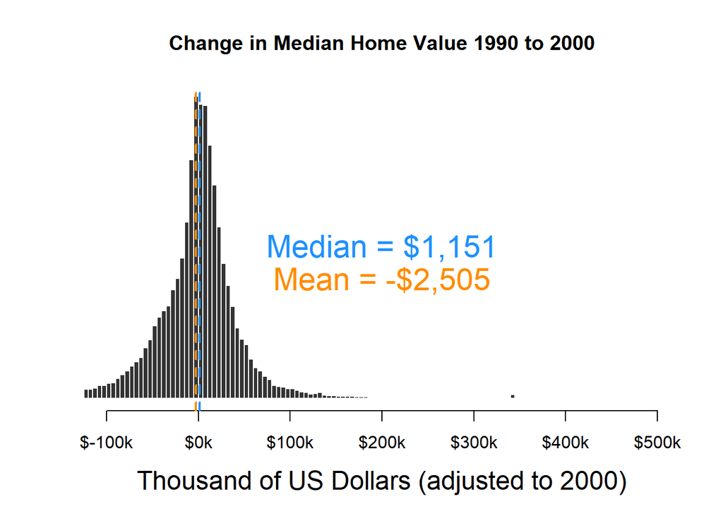

```r
hist( mhv.change/1000, breaks=500,
      xlim=c(-100,500), yaxt="n", xaxt="n",
      xlab="Thousand of US Dollars (adjusted to 2000)", cex.lab=1.5,
      ylab="", main="Change in Median Home Value 1990 to 2000",
      col="gray20", border="white" )
axis( side=1, at=seq( from=-100, to=500, by=100 ),
      labels=paste0( "$", seq( from=-100, to=500, by=100 ), "k" ) )

mean.x <- mean( mhv.change/1000, na.rm=T )
abline( v=mean.x, col="darkorange", lwd=2, lty=2 )
text( x=200, y=1500,
      labels=paste0( "Mean = ", dollar( round(1000*mean.x,0)) ),
      col="darkorange", cex=1.8, pos=3 )
median.x <- median( mhv.change/1000, na.rm=T )
abline( v=median.x, col="dodgerblue", lwd=2, lty=2 )
text( x=200, y=2000,
      labels=paste0( "Median = ", dollar( round(1000*median.x,0)) ),
      col="dodgerblue", cex=1.8, pos=3 )
```

```r
# function to control plot() formatting
jplot <- function( x1, x2, lab1="", lab2="", draw.line=T, ... )
{
    plot( x1, x2,
          pch=19,
          col=gray(0.6, alpha = 0.2),
          cex=2.5,
          bty = "n",
          xlab=lab1,
          ylab=lab2, cex.lab=1.5,
        ... )
    if( draw.line==T ){
        ok <- is.finite(x1) & is.finite(x2)
        lines( lowess(x2[ok]~x1[ok]), col="red", lwd=3 ) }
}
```

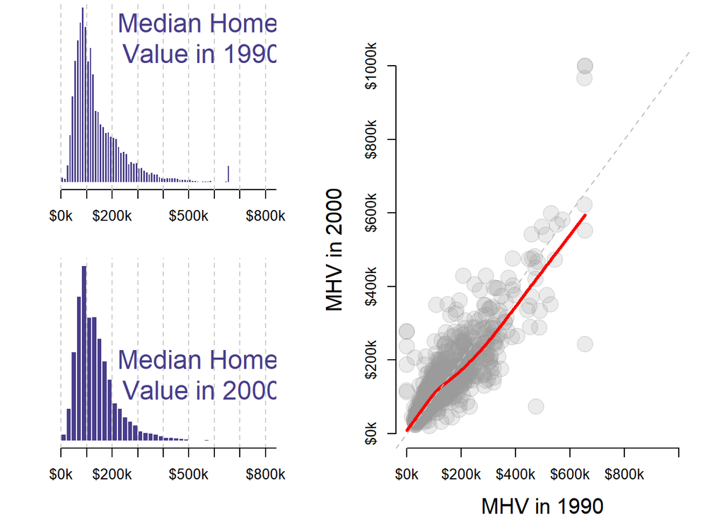

```r
layout.matrix <- matrix( c( 1,3,
                            2,3 ),
                nrow=2, ncol=2, byrow=T )
layout( mat = layout.matrix,
        heights = c(2,2), # Heights of the two rows
        widths =  c(3,4)) # Widths of the two columns
# layout.show(3)
par( mar=c(4,0,0,2) )
hist( mhv.90/1000, breaks=50,
      xlim=c(-200,800), yaxt="n", xaxt="n",
      xlab="", cex.lab=1,
      ylab="", main="",
      col="darkslateblue", border="white" )
axis( side=1, at=seq( from=0, to=1000, by=100 ),
      labels=paste0( "$", seq( from=0, to=1000, by=100 ), "k" ) )
abline( v=seq(0,1000,100), lty=2, col="gray80" )
text( 550, 4000, labels="Median Home \nValue in 1990",
      col="darkslateblue", cex=1.8 )
hist( mhv.00/1000, breaks=50,
      xlim=c(-200,800), yaxt="n", xaxt="n",
      xlab="", cex.lab=1,
      ylab="", main="",
      col="darkslateblue", border="white" )
abline( v=seq(0,1000, 100 ), lty=2, col="gray80" )
text( 550, 3500, labels="Median Home \nValue in 2000",
      col="darkslateblue", cex=1.8 )
axis( side=1, at=seq( from=0, to=1000, by=100 ),
      labels=paste0( "$", seq( from=0, to=1000, by=100 ), "k" ) )
# data reduction - filter 1,000 observations
df <- data.frame( v00=mhv.90/1000, v10=mhv.00/1000 )
df <- sample_n( df, 1000 )
par( mar=c(4,5,3,2) )
jplot( df$v00, df$v10,
       lab1="MHV in 1990", lab2="MHV in 2000",
       xlim=c(0,1000), ylim=c(0,1000),
       axes=F )
abline( a=0, b=1, lty=2, col="gray" )
axis( side=1, at=seq( from=0, to=1000, by=200 ),
      labels=paste0( "$", seq( from=0, to=1000, by=200 ), "k" ) )
axis( side=2, at=seq( from=0, to=1000, by=200 ),
      labels=paste0( "$", seq( from=0, to=1000, by=200 ), "k" ) )
```

**Change in MHV 1990-2000**

```r
# quick filter to remove all of the problematic obs
# but need to go back and see which cases are problematic
mhv.90[ mhv.90 < 10000 ] <- NA
pct.change <- mhv.change / mhv.90
summary( pct.change )
```

```
##     Min.  1st Qu.   Median     Mean  3rd Qu.     Max.     NA's
## -1.00000 -0.15300  0.01203  0.05821  0.21139 28.54641      145
```

```r
# how many cases had increases above 500%
sum( pct.change > 5, na.rm=T )
```

```
## [1] 26
```

```r
# preview tracts with large increases in home values
# to see if increases make sense
d %>%
  filter( pct.change > 5 ) %>%
  head()
```

```
##              tractid mhmval90  mhmval00    hinc90    hinc00      hu90     own90
## 1 fips-01-097-000402 67488.60  593426.5  4999.014  5714.101  673.0189 15.003853
## 2 fips-04-019-000100 73035.87  625000.0  5059.955  9464.000  457.5807 22.886298
## 3 fips-12-099-002600 63800.00  625000.0 15820.000 21944.000  242.0000 20.000000
## 4 fips-13-121-002100 32500.00  261100.0  4999.000 14363.000 1080.0000  8.000000
## 5 fips-17-031-842200 21601.50  281775.9  6861.296 24702.299 1239.2981  9.245283
## 6 fips-17-167-001400 55000.00 1000001.0  8927.000 12321.000  678.0000  4.000000
##     rent90 empclf90    clf90   unemp90    prof90    dpov90   npov90  ag25up90
## 1 651.0111 293.0073 535.0116 242.00434  14.00054 2139.0431 1857.030  812.0255
## 2 382.3900 162.6119 181.9220  19.31012  40.20623  581.4132  358.757  498.2508
## 3 188.0000 448.0000 448.0000   0.00000  62.00000  575.0000  120.000  527.0000
## 4 999.0000 550.0000 732.0000 182.00000  27.00000 2663.0000 1862.000 1426.0000
## 5 738.5132 261.5132 502.2981 240.78491  41.12830 2430.3019 1945.589 1065.5434
## 6 590.0000 294.0000 328.0000  34.00000 126.00000  692.0000  247.000  710.0000
##        hs90      col90  pop90.x    nhwht90    nhblk90     hisp90   asian90
```

[output cut: 20 more lines]

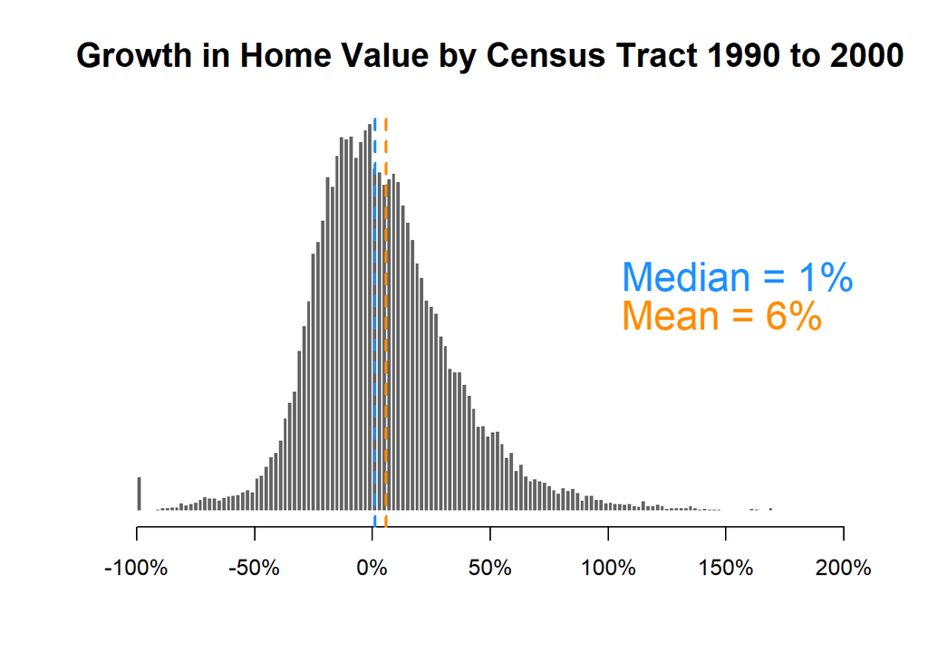

```r
# Plot the percent change variable
hg <-
hist( pct.change, breaks=2000,
      xlim=c(-1,2), yaxt="n", xaxt="n",
      xlab="", cex.main=1.5,
      ylab="", main="Growth in Home Value by Census Tract 1990 to 2000",
      col="gray40", border="white" )
axis( side=1, at=seq( from=-1, to=2, by=0.5 ),
      labels=paste0( seq( from=-100, to=200, by=50 ), "%" ) )
ymax <- max( hg$count )

mean.x <- mean( pct.change, na.rm=T )
abline( v=mean.x, col="darkorange", lwd=2, lty=2 )
text( x=1, y=(0.5*ymax),
      labels=paste0( "Mean = ", round(100*mean.x,0), "%"),
      col="darkorange", cex=1.8, pos=4 )
median.x <- median( pct.change, na.rm=T )
abline( v=median.x, col="dodgerblue", lwd=2, lty=2 )
text( x=1, y=(0.6*ymax),
      labels=paste0( "Median = ", round(100*median.x,0), "%"),
      col="dodgerblue", cex=1.8, pos=4 )
```

```r
# group growth rates by metro area
d$mhv.change <- mhv.change
d$pct.change <- pct.change
d$mhv.00 <- mhv.00
d$mhv.90 <- mhv.90
d %>%
  group_by( cbsaname ) %>%
  summarize( ave.change = median( mhv.change, na.rm=T ),
             ave.change.d = dollar( round(ave.change,0) ),
             growth = 100 * median( pct.change, na.rm=T ) ) %>%
  ungroup() %>%
  arrange( - growth ) %>%
  select( - ave.change ) %>%
  head( 25 ) %>%
  pander()
```

| cbsaname | ave.change.d | growth |
| --- | --- | --- |
| Corvallis, OR | $74,025 | 76.76 |
| Portland-Vancouver-Beaverton, OR-WA | $68,994 | 73.11 |
| Salt Lake City, UT | $62,141 | 70.32 |
| Boulder, CO | $95,512 | 69.84 |
| Provo-Orem, UT | $60,935 | 69.12 |
| Salem, OR | $49,271 | 62.5 |
| Eugene-Springfield, OR | $51,685 | 62.34 |
| Fort Collins-Loveland, CO | $57,856 | 57.5 |
| Longview, WA | $41,345 | 56.24 |
| Missoula, MT | $46,095 | 55.53 |
| Jackson, MI | $28,622 | 54.58 |
| Greeley, CO | $42,178 | 52.85 |
| Wenatchee, WA | $46,440 | 51.6 |
| Detroit-Livonia-Dearborn, MI | $29,372 | 50.52 |
| Yakima, WA | $31,199 | 50.48 |
| Ogden-Clearfield, UT | $42,896 | 49.64 |
| Denver-Aurora, CO | $52,941 | 49.07 |
| Monroe, MI | $42,765 | 48.5 |
| Bay City, MI | $27,094 | 48.16 |
| Logan, UT-ID | $36,163 | 47.55 |
| Eau Claire, WI | $28,211 | 44.11 |
| Madison, WI | $43,488 | 43.22 |
| Sioux Falls, SD | $31,656 | 42.19 |
| Grand Junction, CO | $34,915 | 41.97 |
| Mount Vernon-Anacortes, WA a | $42,577 | 41.68 |

**Part 02**

**Measuring gentrification**

```r
# adjust 1990 home values for inflation
mhv.90 <- d.full$mhmval90 * 1.31
mhv.00 <- d.full$mhmval00
mhv.change <- mhv.00 - mhv.90
# small initial values are skewing percentages
#
# an average home value below $10k is really low -
# these must be mostly vacant lots?
mhv.90[ mhv.90 < 10000 ] <- NA
pct.change <- 100 * ( mhv.change / mhv.90 )
summary( pct.change )
```

```
##     Min.  1st Qu.   Median     Mean  3rd Qu.     Max.     NA's
## -100.000  -15.300    1.203    5.821   21.139 2854.641      145
```

```r
d.full$mhv.90 <- mhv.90
d.full$mhv.00 <- mhv.00
d.full$mhv.change <- mhv.change
d.full$pct.change <- pct.change
```

**Select Gentrification Variables**

```r
head( vars )
```

```
##     type variables
## 1 shared    a15asn
## 2 shared    a15blk
## 3 shared    a15hsp
## 4 shared    a15ntv
## 5 shared    a15wht
## 6 shared    a18und
```

```r
d3 <- select( d.full,

             tractid, cbsa, cbsaname,            # ids / units of analysis

             mhv.90, mhv.00, mhv.change, pct.change,    # home value

             mrent90, mrent00,                   # rent

             vac90, vac00,                       # vacant units

             hinc90, hu90, own90, rent90,        # ses
             hinc00, hu00, own00, rent00,

             empclf90, clf90, unemp90, prof90,   # employment
             empclf00, clf00, unemp00, prof00,

             dpov90, npov90,                     # poverty
             dpov00, npov00,

             ag25up90, hs90, col90,              # education
             ag25up00, hs00, col00,

             pop90.x, nhwht90, nhblk90, hisp90, asian90,   # race
             pop00.x, nhwht00, nhblk00, hisp00, asian00

          ) # end select
d3 <-
  d3 %>%
  mutate(
          # 1990 variables
          p.white.90 = 100 * nhwht90 / pop90.x,
          p.black.90 = 100 * nhblk90 / pop90.x,
          p.hisp.90 = 100 * hisp90 / pop90.x,
          p.asian.90 = 100 * asian90 / pop90.x,
          p.hs.edu.90 = 100 * (hs90+col90) / ag25up90,
          p.col.edu.90 = 100 * col90 / ag25up90,
          p.prof.90 = 100 * prof90 / empclf90,
          p.unemp.90 = 100 * unemp90 / clf90,
          pov.rate.90 = 100 * npov90 / dpov90,
          p.vac.90 = 100 * vac90 / hu90,

          # 2000 variables
          p.white.00 = 100 * nhwht00 / pop00.x,
          p.black.00 = 100 * nhblk00 / pop00.x,
          p.hisp.00 = 100 * hisp00 / pop00.x,
          p.asian.00 = 100 * asian00 / pop00.x,
          p.hs.edu.00 = 100 * (hs00+col00) / ag25up00,
          p.col.edu.00 = 100 * col00 / ag25up00,
          p.prof.00 = 100 * prof00 / empclf00,
          p.unemp.00 = 100 * unemp00 / clf00,
          pov.rate.00 = 100 * npov00 / dpov00,
          p.vac.00 = 100 * vac00 / hu00
)
```

```r
d3 <-
  d3 %>%
  group_by( cbsaname ) %>%
  mutate( metro.mhv.pct.90 = ntile( mhv.90, 100 ),
          metro.mhv.pct.00 = ntile( mhv.00, 100 ),
          metro.median.pay.90 = median( hinc90, na.rm=T ),
          metro.median.pay.00 = median( hinc00, na.rm=T ),
          metro.race.rank.90 = ntile( (100-p.white.90), 100 ) ) %>%
  ungroup() %>%
  mutate( metro.mhv.pct.change = metro.mhv.pct.00 - metro.mhv.pct.90,
          pay.change = metro.median.pay.00 - metro.median.pay.90,
          race.change = p.white.00 - p.white.90,
          mhv.change = mhv.00 - mhv.90 )
```

**Descriptive Statistics of Change Variables**

```r
d3 <-
  d3 %>%
  select( c( "tractid", "cbsa", "cbsaname",
             "mhv.90", "mhv.00", "mhv.change","pct.change",
          "p.white.90", "p.black.90", "p.hisp.90", "p.asian.90",
          "p.hs.edu.90", "p.col.edu.90", "p.prof.90",  "p.unemp.90",
          "pov.rate.90", "mrent90", "p.vac.90", "p.white.00", "p.black.00", "p.hisp.00",
          "p.asian.00", "p.hs.edu.00", "p.col.edu.00", "p.prof.00",
          "p.unemp.00", "pov.rate.00", "metro.mhv.pct.90",
          "metro.mhv.pct.00", "metro.median.pay.90", "metro.median.pay.00",
          "metro.mhv.pct.change", "pay.change", "race.change",
          "metro.race.rank.90") )
```

```r
d3 <- data.frame(d3)
stargazer( d3,
           type=s.type,
           digits=0,
           summary.stat = c("min", "p25","median","mean","p75","max") )
```

| Statistic | Min | Pctl(25) | Median | Mean | Pctl(75) | Max |
| --- | --- | --- | --- | --- | --- | --- |
| mhv.90 | 11,623 | 77,290 | 113,446 | 147,601 | 186,020 | 655,001 |
| mhv.00 | 0 | 81,600 | 119,900 | 144,738 | 173,894 | 1,000,001 |
| mhv.change | -655,001 | -22,178 | 1,100 | -2,995 | 19,777 | 963,976 |
| pct.change | -100 | -15 | 1 | 6 | 21 | 2,855 |
| p.white.90 | 0 | 64 | 87 | 74 | 95 | 100 |
| p.black.90 | 0 | 1 | 3 | 12 | 10 | 100 |
| p.hisp.90 | 0 | 1 | 3 | 10 | 9 | 100 |
| p.asian.90 | 0 | 0 | 1 | 3 | 3 | 94 |
| p.hs.edu.90 | 0 | 69 | 74 | 74 | 80 | 100 |
| p.col.edu.90 | 0 | 10 | 18 | 22 | 30 | 100 |
| p.prof.90 | 0 | 17 | 25 | 27 | 34 | 100 |
| p.unemp.90 | 0 | 4 | 5 | 7 | 8 | 64 |
| pov.rate.90 | 0 | 4 | 8 | 12 | 16 | 100 |
| mrent90 | 0 | 298 | 396 | 430 | 527 | 1,001 |
| p.vac.90 | 0 | 4 | 6 | 8 | 10 | 100 |
| p.white.00 | 0 | 47 | 78 | 67 | 91 | 100 |
| p.black.00 | 0 | 1 | 4 | 14 | 14 | 100 |
| p.hisp.00 | 0 | 2 | 4 | 13 | 15 | 100 |
| p.asian.00 | 0 | 1 | 2 | 5 | 5 | 95 |
| p.hs.edu.00 | 0 | 67 | 72 | 72 | 77 | 100 |
| p.col.edu.00 | 0 | 12 | 21 | 26 | 36 | 100 |
| p.prof.00 | 0 | 23 | 31 | 34 | 43 | 100 |
| p.unemp.00 | 0 | 3 | 5 | 6 | 8 | 100 |
| pov.rate.00 | 0 | 4 | 9 | 12 | 17 | 100 |
| metro.mhv.pct.90 | 1 | 20 | 41 | 45 | 68 | 100 |
| metro.mhv.pct.00 | 1 | 20 | 41 | 45 | 68 | 100 |
| metro.median.pay.90 | 14,871 | 28,906 | 32,457 | 32,924 | 35,833 | 52,374 |
| metro.median.pay.00 | 23,012 | 39,457 | 43,139 | 45,054 | 49,522 | 73,701 |
| metro.mhv.pct.change | -99 | -5 | 0 | 0 | 6 | 99 |
| pay.change | 4,930 | 9,775 | 11,441 | 12,130 | 14,001 | 26,211 |
| race.change | -100 | -12 | -5 | -8 | -2 | 100 |
| metro.race.rank.90 | 1 | 20 | 41 | 45 | 68 | 100 |

**Operationalizing Gentrification;**

*Based on proposal by Sarah J. to be used by group, the following factor will predict the tract gentrification (- Low home values, - Low rents,- High rate of vacant units, - High proportion of racial/ethnic minority residents, - High rate of unemployment, - Low % with college degree or more education and - High poverty rate)*

```r
## Predicted factors that make a tract eligible for gentrification
# home value in lower than average home in a metro in 1990
lowhomeval.1990 <- d3$metro.mhv.pct.90 < 50
# vacancies above 75th percentile
vacant.1990 <- d3$p.vac.90 > 9
# median rent below the 25th percentile
lowrent.1990 <- d3$mrent90 < 168
# above average diversity for metro
diverse.1990 <- d3$metro.race.rank.90 > 50
# unemployment above 75th percentile
unemployment.1990 <- d3$p.unemp.90 > 8
# college or more education below the 25th percentile
lowed.1990 <- d3$p.col.edu.90 < 10
# poverty rate above 75h percentile
highpoverty.1990 <- d3$pov.rate.90 > 16
sum( lowhomeval.1990, na.rm = T )
```

```
## [1] 34602
```

```r
sum( vacant.1990, na.rm = T )
```

```
## [1] 17610
```

```r
sum( lowrent.1990, na.rm = T )
```

```
## [1] 1464
```

```r
sum( diverse.1990, na.rm = T )
```

```
## [1] 24415
```

```r
sum( unemployment.1990, na.rm = T )
```

```
## [1] 14501
```

```r
sum( lowed.1990, na.rm = T )
```

```
## [1] 14911
```

```r
sum( highpoverty.1990, na.rm = T )
```

```
## [1] 14801
```

```r
gent.candidate <- sum( lowhomeval.1990 & vacant.1990  & lowrent.1990 &
                         diverse.1990 & unemployment.1990 & lowed.1990 &
                         highpoverty.1990, na.rm = T )
gent.candidate
```

```
## [1] 418
```

**Using all of the criteria listed, only 418 tracts were eligible for gentrification**

```r
gent.candidate2 <- sum(( lowhomeval.1990 | vacant.1990 | lowrent.1990 ) &
                          diverse.1990 & (unemployment.1990 | highpoverty.1990 ) &
                          lowed.1990, na.rm = T )
gent.candidate2
```

```
## [1] 7315
```

**By combining the three property criteria (so a tract can be selected if it has low home values and/or high vacancies and/or low rent), and combining the two income factors ( unemployment and/or high poverty rate ), the number of tracts eligible for gentrification increased 7315.**

```r
# home values increased more than overall city gains
# change in percentile rank within the metro
mhv.pct.increase <- d3$metro.mhv.pct.change > 0
# faster than average growth
# 25% growth in value is median for the country
home.val.rise <- d3$pct.change > 25
# proportion of whites increases by more than 3 percent
# measured by increase in white
loss.diversity <- d3$race.change > 3
```

```r
gentrified <- ( lowhomeval.1990 | vacant.1990 | lowrent.1990 ) &
                          diverse.1990 & (unemployment.1990 | highpoverty.1990 ) &
                          lowed.1990 & mhv.pct.increase & home.val.rise & loss.diversity
num.gentrified <- sum( gentrified, na.rm=T )
num.gentrified
```

```
## [1] 135
```

```r
gent.candidate2
```

```
## [1] 7315
```

```r
pct.gentrified <- num.gentrified / gent.candidate2
pct.gentrified
```

```
## [1] 0.01845523
```

**Using this approach, only 1.85% of eligible tracts became gentrified from 1990 to 2000.**

```r
# small initial values are skewing percentages
#
# an average home value below $10k is really low -
# these must be mostly vacant lots?
mhv.90[ mhv.90 < 1000 ] <- NA
pct.change <- 100 * ( mhv.change / mhv.90 )
summary( pct.change )
```

```
##     Min.  1st Qu.   Median     Mean  3rd Qu.     Max.     NA's
## -100.000  -15.300    1.203    5.821   21.139 2854.641      145
```

**Part 03**

*Spatial Patterns*

```r
crosswalk <- read.csv( "https://raw.githubusercontent.com/DS4PS/cpp-529-master/master/data/cbsatocountycrosswalk.csv",  stringsAsFactors=F, colClasses="character" )
# search for city names by strings, use the ^ anchor for "begins with"
grep( "^MIL", crosswalk$msaname, value=TRUE )
```

```
## [1] "MILWAUKEE-WAUKESHA, WI" "MILWAUKEE-WAUKESHA, WI" "MILWAUKEE-WAUKESHA, WI"
## [4] "MILWAUKEE-WAUKESHA, WI"
```

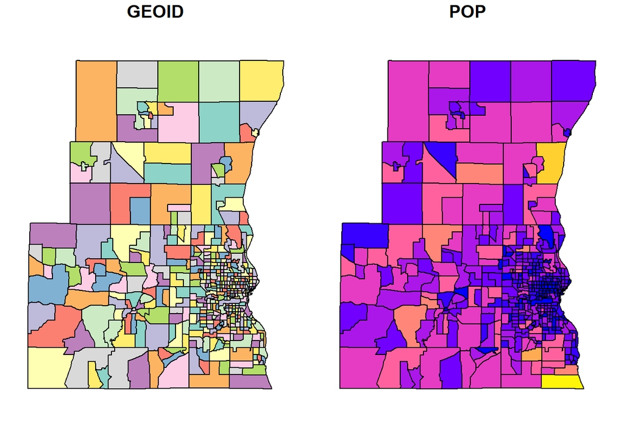

```r
these.MKE <- crosswalk$msaname == "MILWAUKEE-WAUKESHA, WI"
these.fips <- crosswalk$fipscounty[ these.MKE ]
these.fips <- na.omit( these.fips )
state.fips <- substr( these.fips, 1, 2 )
county.fips <- substr( these.fips, 3, 5 )
MKE <-
get_acs( geography = "tract", variables = "B01003_001",
         state = "55", county = county.fips[state.fips=="55"],
         geometry = TRUE, progress_bar = FALSE ) %>%
         select( GEOID, estimate ) %>%
         rename( POP=estimate )
plot( MKE)
```

```r
# create small dataframe for the merge
df <- data.frame(  tractid=d$tractid,
        mhv.90, mhv.00,  mhv.change,  pct.change, loss.diversity, lowhomeval.1990,
        unemployment.1990, d3$p.unemp.90, d3$p.unemp.00, d3$pov.rate.90, d3$pov.rate.00, d3$pay.change,
        d3$race.change )
# create GEOID that matches GIS format
# create a geoID for merging by tract
df$GEOID <- substr( df$tractid, 6, 18 )  # extract codes
df$GEOID <- gsub( "-", "", df$GEOID )    # remove hyphens
class( df$GEOID )
```

```
## [1] "character"
```

```r
head( df$GEOID )
```

```
## [1] "01001020100" "01001020200" "01001020300" "01001020400" "01001020500"
## [6] "01001020600"
```

```r
nrow( MKE )
```

```
## [1] 431
```

```r
mke <- merge( MKE, df, by.x="GEOID", by.y="GEOID" )
nrow( mke )
```

```
## [1] 429
```

[figure not shown]

```r
mke <- as_Spatial( mke )
mke <- spTransform( mke, CRS("+init=epsg:3395"))
mke_dorling <- cartogram_dorling( x=mke, weight = "mhv.00", k=0.05 )
plot( mke_dorling )
```

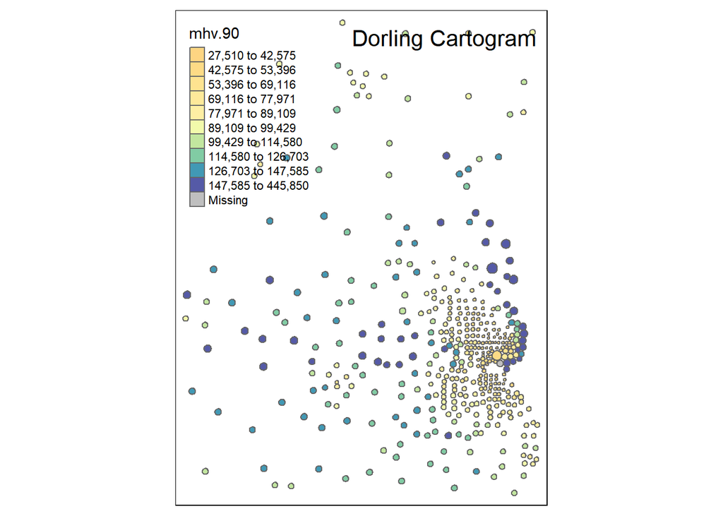

```r
tm_shape( mke_dorling ) +
  tm_polygons( col="mhv.90", n=10, style="quantile", palette="Spectral" ) +
  tm_layout( "Dorling Cartogram", title.position=c("right","top") )
```

**Home Values** *Describe the distribution of home values in 1990 - where are high and low-value tracts located in the city/cities?*

*In 1990, high-value tracts were concentrated north of downtown along the lakefront (the far right edge of the map) and scattered through the northern and western suburbs. Low-value tracts are located in the central city, southern city and suburbs, and northwest areas of the city*.

```r
tm_shape( mke_dorling) +
  tm_polygons( col="mhv.change", n=10, style="quantile", palette="Spectral" ) +
  tm_layout( "Dorling Cartogram", title.position=c("right","top") )
```

```
## Variable(s) "mhv.change" contains positive and negative values, so midpoint is set to 0. Set midpoint = NA to show the full spectrum of the color palette.
```

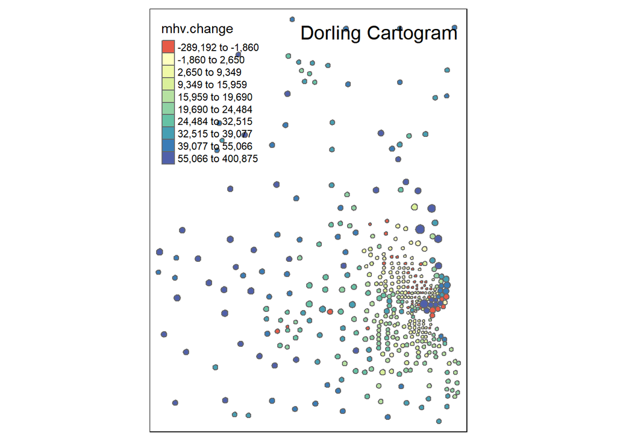

**Compare values in 2000 to changes in values from 1990-2000. Do the largest gains occur in tracts with above or below-average home prices in 2000?**

*The most striking areas with gains from 1990-2000 were lower-value but adjacent to high-value areas in 1990. There is a cluster with gains downtown and just west of the lakefront, while areas along the lake downtown had losses during this period.*

```r
tm_shape( mke_dorling ) +
  tm_polygons( col="pct.change", n=10, style="quantile", palette="Spectral" ) +
  tm_layout( "Dorling Cartogram", title.position=c("right","top") )
```

```
## Variable(s) "pct.change" contains positive and negative values, so midpoint is set to 0. Set midpoint = NA to show the full spectrum of the color palette.
```

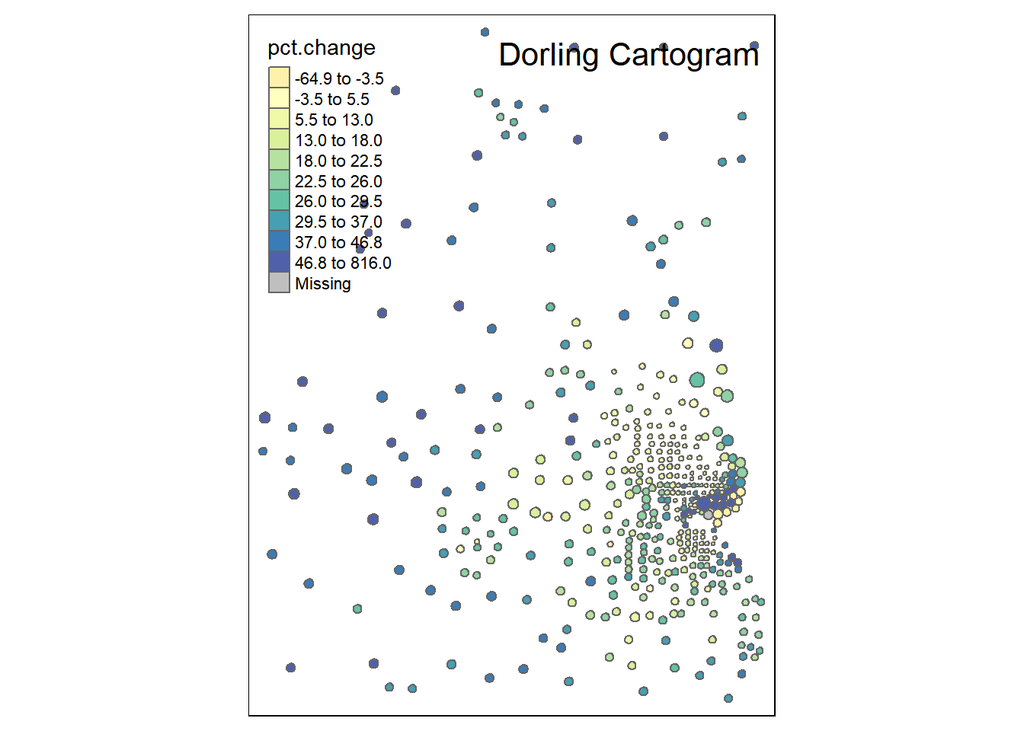

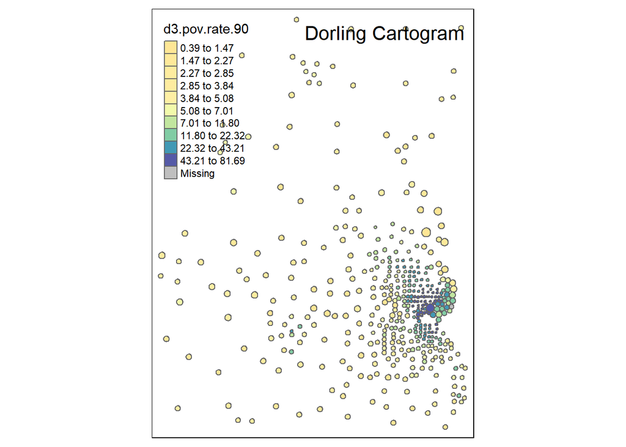

```r
tm_shape( mke_dorling ) +
  tm_polygons( col="d3.pov.rate.90", n=10, style="quantile", palette="Spectral" ) +
  tm_layout( "Dorling Cartogram", title.position=c("right","top") )
```

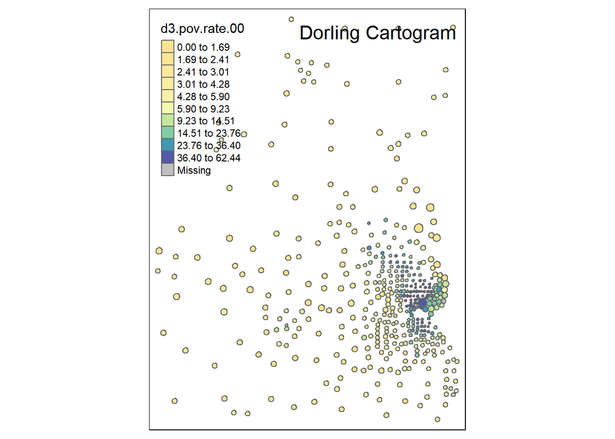

```r
tm_shape( mke_dorling ) +
  tm_polygons( col="d3.pov.rate.00", n=10, style="quantile", palette="Spectral" ) +
  tm_layout( "Dorling Cartogram", title.position=c("right","top") )
```

```r
tm_shape( mke_dorling ) +
  tm_polygons( col="d3.race.change", n=10, style="quantile", palette="Spectral" ) +
  tm_layout( "Dorling Cartogram", title.position=c("right","top") )
```

```
## Variable(s) "d3.race.change" contains positive and negative values, so midpoint is set to 0. Set midpoint = NA to show the full spectrum of the color palette.
```

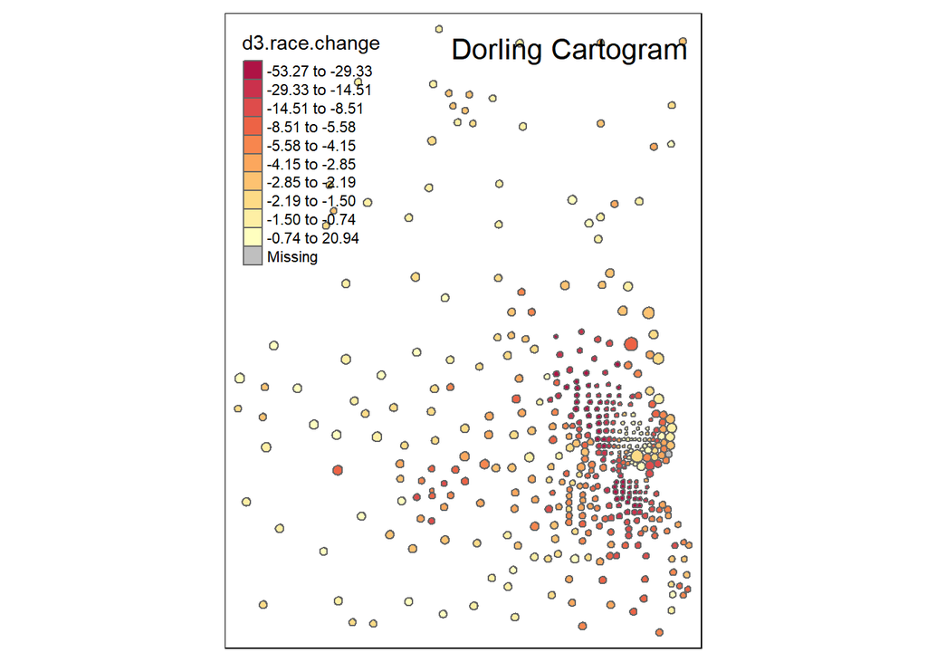

*These maps along with the map above showing percent change in median home value change from 1990 to 2000 help show the areas where in 1990 there was very high poverty and between 1990 and 2000 property values rose at the same time that the racial mix of residents stayed fairly stable or became more white. It does appear that the area just west of the lakefront in the downtown area experienced gentrification during this time period.*